# Project Foundations for Data Science: FoodHub Data Analysis

### **Question 2:** What are the datatypes of the different columns in the dataset? (The info() function can be used)

```python
df.info()
```

```
<class 'pandas.core.frame.DataFrame'>
RangeIndex: 1898 entries, 0 to 1897
Data columns (total 11 columns):
 #   Column                 Non-Null Count  Dtype
---  ------                 --------------  -----
 0   order_id               1898 non-null   int64
 1   customer_id            1898 non-null   int64
 2   restaurant_name        1898 non-null   object
 3   cuisine_type           1898 non-null   object
 4   cost_of_the_order      1898 non-null   float64
 5   day_of_the_week        1898 non-null   object
 6   rating                 1898 non-null   object
 7   food_preparation_time  1898 non-null   int64
 8   delivery_time          1898 non-null   int64
 9   total_time             1898 non-null   int64
 10  revenue                1898 non-null   float64
dtypes: float64(2), int64(5), object(4)
memory usage: 163.2+ KB
```

### **Question 3:** Are there any missing values in the data? If yes, treat them using an appropriate method

```python
df.isnull().sum()
```

|  | 0 |
| --- | --- |
| order_id | 0 |
| customer_id | 0 |
| restaurant_name | 0 |
| cuisine_type | 0 |
| cost_of_the_order | 0 |
| day_of_the_week | 0 |
| rating | 0 |
| food_preparation_time | 0 |
| delivery_time | 0 |
| total_time | 0 |
| revenue | 0 |

**dtype:** int64

#### Observations:

Although in the previous code we could infer there are no missing values in the data, we had to make sure with an isnull count. In this case, is null indicates if there are any null values and.sum summs them up to see the total nulls per column. In this particular case, there are no nulls, which indicates the information is complete.

### **Question 4:** Check the statistical summary of the data. What is the minimum, average, and maximum time it takes for food to be prepared once an order is placed?

```python
df.describe(include="all")  #this gives a summary of the data, and I used include all to include all of the columns and all of the information it can summarize.
```

|  | order_id | customer_id | restaurant_name | cuisine_type | cost_of_the_order | day_of_the_week | rating | food_preparation_time | delivery_time | total_time | revenue |
| --- | --- | --- | --- | --- | --- | --- | --- | --- | --- | --- | --- |
| count | 1.898000e+03 | 1898.000000 | 1898 | 1898 | 1898.000000 | 1898 | 1898 | 1898.000000 | 1898.000000 | 1898.000000 | 1898.000000 |
| unique | NaN | NaN | 178 | 14 | NaN | 2 | 4 | NaN | NaN | NaN | NaN |
| top | NaN | NaN | Shake Shack | American | NaN | Weekend | Not given | NaN | NaN | NaN | NaN |
| freq | NaN | NaN | 219 | 584 | NaN | 1351 | 736 | NaN | NaN | NaN | NaN |
| mean | 1.477496e+06 | 171168.478398 | NaN | NaN | 16.498851 | NaN | NaN | 27.371970 | 24.161749 | 51.533720 | 3.248842 |
| std | 5.480497e+02 | 113698.139743 | NaN | NaN | 7.483812 | NaN | NaN | 4.632481 | 4.972637 | 6.833603 | 2.295598 |
| min | 1.476547e+06 | 1311.000000 | NaN | NaN | 4.470000 | NaN | NaN | 20.000000 | 15.000000 | 35.000000 | 0.000000 |
| 25% | 1.477021e+06 | 77787.750000 | NaN | NaN | 12.080000 | NaN | NaN | 23.000000 | 20.000000 | 47.000000 | 1.812000 |
| 50% | 1.477496e+06 | 128600.000000 | NaN | NaN | 14.140000 | NaN | NaN | 27.000000 | 25.000000 | 52.000000 | 2.121000 |
| 75% | 1.477970e+06 | 270525.000000 | NaN | NaN | 22.297500 | NaN | NaN | 31.000000 | 28.000000 | 56.000000 | 5.574375 |
| max | 1.478444e+06 | 405334.000000 | NaN | NaN | 35.410000 | NaN | NaN | 35.000000 | 33.000000 | 68.000000 | 8.852500 |

#### Observations:

This gives us a summary of the data, and according to the data summary the minimum time it takes to prepare food is 20 minutes, the maximum is 35 minutes but the average is is 27 minutes.

### **Question 5:** How many orders are not rated?

```python
ratingcount = (df['rating'] == 'Not given').sum() #we indicate which column, which in this case is rating, and we equal to what value we want
#from the database. In this case, its the "not given"; from there, we get .sum() fuction tu sum all of those values and give us the direct value
print(ratingcount)
```

```
736
```

Although this is an alternative to the way of usually doing it, this tell us the value directly of the orders that are not rated. In this specific data set, the orders are specifcly named "Not given". We know this because of the data summary (what is the most commun value for the rating column) and because of the df.head function.

```python
df['rating'].value_counts()
```

| rating | count |
| --- | --- |
| Not given | 736 |
| 5 | 588 |
| 4 | 386 |
| 3 | 188 |

**dtype:** int64

#### Observations:

Assuming the rating values are from 1 to 5, we can clearly see that there are rarely any "bad ratings" as the lowest rating given is 3 and even so, it's the least given rating. Although majority of the restaurants are not given a rating, overall there seems to be a high satisfaction because the rest of the ratings tend to be high.

### Exploratory Data Analysis (EDA)

[output not shown]

### **Question 6:** Explore all the variables and provide observations on their distributions. (Generally, histograms, boxplots, countplots, etc. are used for univariate exploration)

### Order ID

```python
df['order_id'].nunique()
```

```
1898
```

### Customer ID

```python
df['customer_id'].value_counts()
```

| customer_id | count |
| --- | --- |
| 52832 | 13 |
| 47440 | 10 |
| 83287 | 9 |
| 250494 | 8 |
| 259341 | 7 |
| ... | ... |
| 385426 | 1 |
| 254913 | 1 |
| 289597 | 1 |
| 74412 | 1 |
| 397537 | 1 |

1200 rows × 1 columns

**dtype:** int64

```python
df['customer_id'].nunique()
```

```
1200
```

Due to the fact that there are 1898 orders and only 1200 customers, there is obviously a repeated amount of customers who buy again in the same app.

### Restaurant Names

```python
df['restaurant_name'].nunique()
```

```
178
```

```python
df['restaurant_name'].value_counts()
```

| restaurant_name | count |
| --- | --- |
| Shake Shack | 219 |
| The Meatball Shop | 132 |
| Blue Ribbon Sushi | 119 |
| Blue Ribbon Fried Chicken | 96 |
| Parm | 68 |
| ... | ... |
| Sushi Choshi | 1 |
| Dos Caminos Soho | 1 |
| La Follia | 1 |
| Philippe Chow | 1 |
| 'wichcraft | 1 |

178 rows × 1 columns

**dtype:** int64

### Cuisine Types

```python
# Check the number of unique cuisine types
df['cuisine_type'].nunique()
```

```
14
```

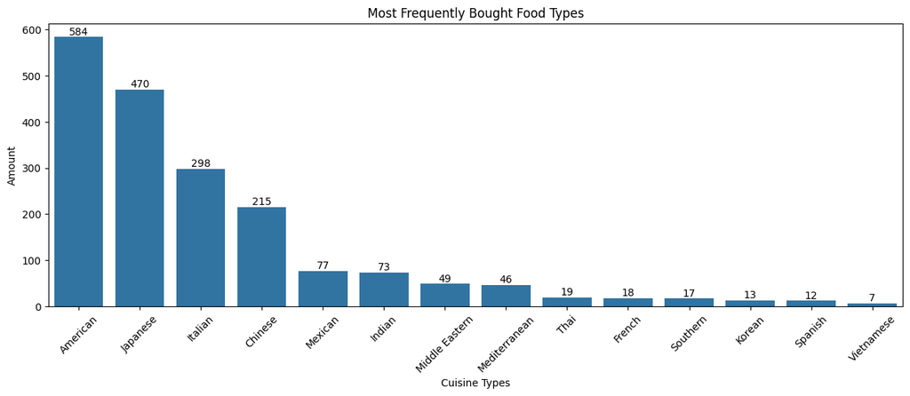

```python
plt.figure(figsize=(15, 5))

# do the value counts to check how much is each value of each cuisine type
cuisine_counts = df['cuisine_type'].value_counts()

# Create a barplot
bar_plot = sns.barplot(x=cuisine_counts.index, y=cuisine_counts.values)

# Add labels using bar_label
bar_plot.bar_label(bar_plot.containers[0])

plt.xticks(rotation=45)
plt.title("Most Frequently Bought Food Types")
plt.xlabel("Cuisine Types")
plt.ylabel("Amount")
plt.show()

#Investigated this in stack overflow to be able to add labels to the bars of each value
```

### Cost of Order

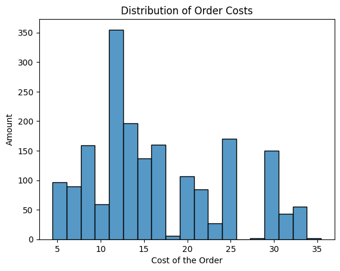

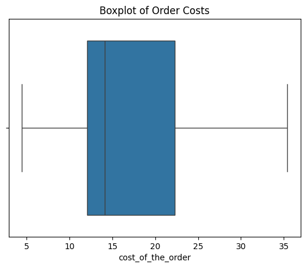

```python
sns.histplot(data=df, x='cost_of_the_order')
plt.title("Distribution of Order Costs")
plt.xlabel("Cost of the Order")
plt.ylabel("Amount")
plt.show()

# Boxplot for cost of the order
sns.boxplot(data=df, x='cost_of_the_order')
plt.title("Boxplot of Order Costs")
plt.show()
```